# CHDH SNA 4

[Johan Koskinen](https://psychologicalsciences.unimelb.edu.au/research/msps-research-groups/Social_Networks_Laboratory)

2026-03-19

# Overview

- Different types of data
- Imperfect data

Load packages

```r
library("sna")
library("network")
library('RSiena')
```

# Two-mode data

Consider boards $i=1,\ldots,m$ and directors $j=1,\ldots,m$, and let
$$\begin{equation*}
X_{ij}= \left\{
\begin{array}{lr}
1,&\text{if board } i \text{ has as a board member director }
j\\
0,&\text{else}
\end{array}
\right.
\end{equation*}$$

## Data

A subset of the data on Swedish interlocking directors used in Koskinen and Edling (2012)

```r
SWE.b.t1 <- as.matrix(read.table("https://raw.githubusercontent.com/johankoskinen/CHDH-SNA/main/data/SWE-Borard-t1.txt"))

SWE.b.t2 <- as.matrix(read.table("https://raw.githubusercontent.com/johankoskinen/CHDH-SNA/main/data/SWE-Borard-t2.txt"))
```

Find out number of nodes in nodesets:

```r
nrsend <- dim( SWE.b.t1 )[1]
nrrec <- dim( SWE.b.t1 )[2]
```

To create bipartite network objects you need two node sets and must create the node sets too

```r
senders <- sienaNodeSet(nrsend, nodeSetName="senders")
receivers <- sienaNodeSet(nrrec, nodeSetName="receivers")
```

Define the dependent variable:

```r
myBipNet <- sienaDependent(array(c( SWE.b.t1,SWE.b.t2), dim=c(nrsend,nrrec,2)),# not square!
                      "bipartite",# this is the type (as opposed to one-mode)
                      nodeSet=c("senders","receivers")# associate rows and columns with nodesets
                      )
```

At this point we do not have any other variables:

```r
bipData <- sienaDataCreate(myBipNet,nodeSets=list(senders,receivers))
```

### What effects?

Get effects table for model specification:

```r
bipEffects <- getEffects(bipData)
```

### Descriptives

Generate initial descriptive output file:

```r
print01Report(bipData,modelname="bip1")
```

> We should really always look at the print-report

#### Four-cycles

```r
bipEffects <- includeEffects(bipEffects,cycle4,name="myBipNet")
```

```
##   effectNumber effectName   shortName include fix   test  initialValue parm
## 1 10           4 cycles (#) cycle4    TRUE    FALSE FALSE          0   1
```

#### Possible effects

```r
 bipEffects <- includeEffects(bipEffects,outActSqrt)
```

```
##   effectNumber effectName                  shortName  include fix   test
## 1 34           outdegree - activity (sqrt) outActSqrt TRUE    FALSE FALSE
##   initialValue parm
## 1          0   0
```

```r
# Bypass bug related to initial values for bipartite network rates:
# bipEffects <- setEffect(bipEffects,Rate,name="leisure",initialValue=1.0,period=1,type="rate")
```

## Algorthm

```r
bip.algo <- sienaAlgorithmCreate( projname = 'bip.mod' )
```

Estimate!

```r
bip.mod.ans <- siena07( bip.algo,
                         data = bipData ,
                         effects =bipEffects ,
                         batch = TRUE,
                         returnDeps = TRUE )
```

## Results

Check estimation results

```r
bip.mod.ans
```

```
## Estimates, standard errors and convergence t-ratios
##
##                                       Estimate   Standard   Convergence
##                                                    Error      t-ratio
##
## Rate parameters:
##   0       Rate parameter               1.9374  ( 0.1476   )
##
## Other parameters:
##   1. eval outdegree (density)         -2.0017  ( 0.7341   )    0.0452
##   2. eval 4 cycles (1)                 0.3910  ( 0.0766   )   -0.0123
##   3. eval outdegree - activity (sqrt) -0.1702  ( 0.1853   )    0.0428
##
## Overall maximum convergence ratio:    0.0511
##
##
## Total of 2100 iteration steps.
```

## GOF

```r
(gofi0 <- sienaGOF(bip.mod.ans, IndegreeDistribution, verbose=TRUE, join=TRUE,
     varName="myBipNet"))
```

```
## Detected 1000 iterations and 1 group.
```

```
## Calculating auxiliary statistics for period  1 .
```

```
##   Period 1
```

```
##   > Completed  100  calculations  > Completed  200  calculations  > Completed  300  calculations  > Completed  400  calculations  > Completed  500  calculations  > Completed  600  calculations  > Completed  700  calculations  > Completed  800  calculations  > Completed  900  calculations  > Compl…
```

```
## Siena Goodness of Fit ( IndegreeDistribution ), all periods
## =====
## Monte Carlo Mahalanobis distance test p-value:  0.05
## -----
## One tailed test used  (i.e. estimated probability of greater distance than observation).
## -----
## Calculated joint MHD = ( 18.5 ) for current model.
```

```r
(gofo0 <- sienaGOF(bip.mod.ans, OutdegreeDistribution, verbose=TRUE, join=TRUE,
     varName="myBipNet"))
```

```
## Detected 1000 iterations and 1 group.
```

```
## Calculating auxiliary statistics for period  1 .
```

```
##   Period 1
```

```
##   > Completed  100  calculations  > Completed  200  calculations  > Completed  300  calculations  > Completed  400  calculations  > Completed  500  calculations  > Completed  600  calculations  > Completed  700  calculations  > Completed  800  calculations  > Completed  900  calculations  > Compl…
```

```
## Siena Goodness of Fit ( OutdegreeDistribution ), all periods
## =====
## Monte Carlo Mahalanobis distance test p-value:  0.109
## -----
## One tailed test used  (i.e. estimated probability of greater distance than observation).
## -----
## Calculated joint MHD = ( 14.07 ) for current model.
```

Note now that the indegree
$$\sum_i x_{ij}$$
will be, for each director $j$, the number of boards that choose director $j$

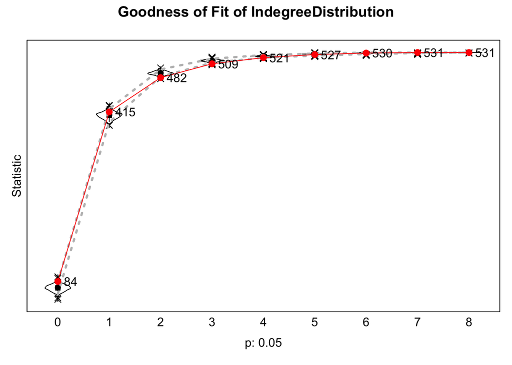

```r
plot(gofi0)
```

The outdegree
$$\sum_j x_{ij}$$
will be, for each board $i$, the number of directors the board has

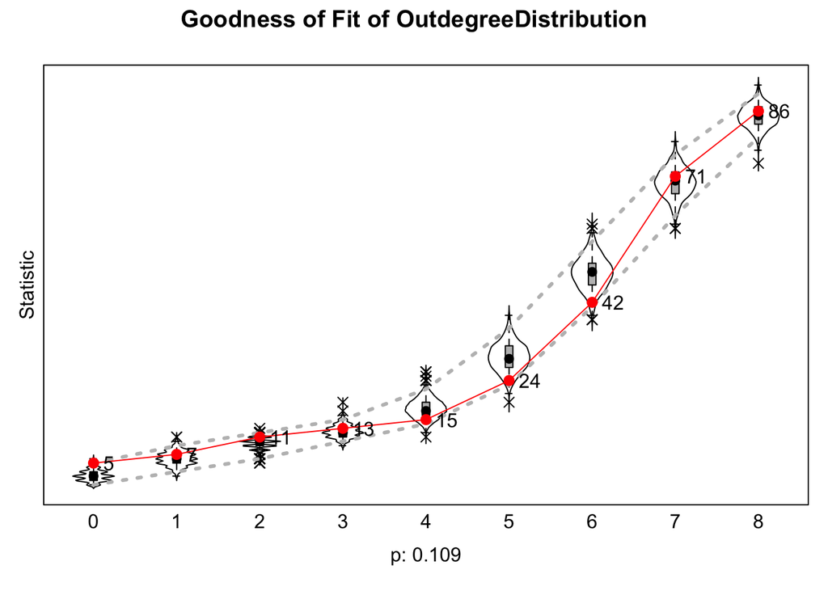

```r
plot(gofo0)
```

> This simple model actually does relatively OK in terms of not creating boards that have too many or too few directors!

There is no simple way (to the best of my knowledge) of restricting the degree distribution. You may set the maximum using `MaxDegree=c(myBipNet=15)` in `sienaAlgorithmCreate`. There are some relevant effects as well.

# One-mode & two-mode

Consider now the Glasgow dataset and assume that we will model friendship $X$ alongside
$$\begin{equation*}
z_{ij}^{(r)}= \left\{
\begin{array}{lr}
1,&\text{if pupil } i \text{ engages in category } j \text{ of
activity } r\\
0,&\text{else}
\end{array}
\right.
\end{equation*}$$
for a number $r=1,\ldots,R$ different activities. The activities will be

- Leisure activities
- Music genres
- Different drugs

```r
temp <- tempfile()
download.file("http://www.stats.ox.ac.uk/~snijders/siena/Glasgow_bip_data.zip",temp)

# read the friendship data:
friendship1 <- as.matrix(read.table(unz(temp,"Glasgow-1-net.dat")))
friendship2 <- as.matrix(read.table(unz(temp,"Glasgow-2-net.dat")))

# now demographic info:
demographics <- as.matrix(read.table(unz(temp,"Glasgow-sex-birthyear.dat")))

# now the bipartite data:
leisure1 <- as.matrix(read.table(unz(temp,"GL-1-lsr.dat")))
leisure2 <- as.matrix(read.table(unz(temp,"GL-2-lsr.dat")))
music1 <- as.matrix(read.table(unz(temp,"GL-1-mus.dat")))
music2 <- as.matrix(read.table(unz(temp,"GL-2-mus.dat")))
drugs1 <- as.matrix(read.table(unz(temp,"GL-1-drg.dat")))
drugs2 <- as.matrix(read.table(unz(temp,"GL-2-drg.dat")))

unlink(temp)
```

### Recoding

Recode the behaviours into meaningful affiliation info:

```r
leisure1[leisure1 %in% c(2,3,4)] <- 0
# leisure1[leisure1 == 2] <- 1
leisure2[leisure2 %in% c(2,3,4)] <- 0
# leisure2[leisure2 == 2] <- 1
drugs1[drugs1 %in% c(1)] <- 0
drugs1[drugs1 %in% c(2,3,4)] <- 1
drugs2[drugs2 %in% c(1)] <- 0
drugs2[drugs2 %in% c(2,3,4)] <- 1
```

Recode valued friendship data & identify missings:

```r
friendship1[friendship1 == 2] <- 1
friendship1[friendship1 == 9] <- NA
friendship2[friendship2 == 2] <- 1
friendship2[friendship2 == 9] <- NA
```

We need to find out the number of nodes in different nodesets as well as the number of items in different scales:

```r
(nrpupils <- dim(leisure1)[1])
```

```
## [1] 160
```

```r
(nrleisureItems <- dim(leisure1)[2])
```

```
## [1] 15
```

```r
(nrmusicItems <- dim(music1)[2])
```

```
## [1] 16
```

```r
(nrdrugsItems <- dim(drugs1)[2])
```

```
## [1] 14
```

## Node sets

We now have 4 different node sets. Define the different node sets for R:

```r
pupils <- sienaNodeSet(nrpupils, nodeSetName="pupils")
leisureItems <- sienaNodeSet(nrleisureItems, nodeSetName="leisureItems")
musicItems <- sienaNodeSet(nrmusicItems, nodeSetName="musicItems")
drugsItems <- sienaNodeSet(nrdrugsItems, nodeSetName="drugsItems")
```

## Dependent variables

We will format each affiliation network as a dependent variable

```r
leisure <- sienaDependent(array(c(leisure1, leisure2),
                dim=c(nrpupils, nrleisureItems,2)),
                "bipartite", nodeSet=c("pupils", "leisureItems"))
music <- sienaDependent(array(c(music1, music2),
                dim=c(nrpupils, nrmusicItems,2)),
                "bipartite", nodeSet=c("pupils", "musicItems"))
drugs <- sienaDependent(array(c(drugs1, drugs2),
                dim=c(nrpupils, nrdrugsItems,2)),
                "bipartite", nodeSet=c("pupils", "drugsItems"))
```

in addition to the dependent one-mode friendship network

```r
friendship <- sienaDependent(array(c(friendship1, friendship2),
                dim=c(nrpupils, nrpupils,2)), nodeSet="pupils")
```

## Covariate

Different node sets may have different covariates. Here we only use the sex of the pupils:

```r
sex.F <- coCovar(demographics[, 1], nodeSet="pupils")
```

## Data create

We have now defined all of the different variables and can combine them in an RSiena dataset

```r
bipData <- sienaDataCreate(friendship,# one-mode network
                           leisure, # pupil affiliation with leisure activity
                           music, # pupil affiliation with different music styles
                           drugs, # pupil affiliation with different drugs
                           sex.F, # sex (male/female; 0/1)
                           nodeSets=list(pupils, leisureItems, musicItems, drugsItems)# the different node sets
                           )
```

## Effects

Get effects table for model specification:

```r
bipEffects <- getEffects(bipData)
```

## Descriptives

Generate initial descriptive outputfile:

```r
print01Report(bipData, modelname="Bipartite-illustration")
```

Look at the generated output file “Bipartite-illustration.out” to see how RSiena interpreted the directives provided and to get an impression of the data (eyeball the degrees, look at occurrence of missings, look at Jaccard indices).

## Specify the model

When we specify the effects to include, pay special attention to the `name` variable

```r
bipEffects <- includeEffects(bipEffects, transTrip, name="friendship")
```

```
##   effectNumber effectName                      shortName include fix   test
## 1 21           friendship: transitive triplets transTrip TRUE    FALSE FALSE
##   initialValue parm
## 1          0   0
```

```r
bipEffects <- includeEffects(bipEffects, from, name="friendship",
                            interaction1="leisure")
```

```
##   effectNumber effectName                             shortName include fix
## 1 485          friendship: from leisure agreement (#) from      TRUE    FALSE
##   test  initialValue parm
## 1 FALSE          0   0
```

```r
bipEffects <- includeEffects(bipEffects, from, name="friendship",
                            interaction1="music")
```

```
##   effectNumber effectName                           shortName include fix
## 1 555          friendship: from music agreement (#) from      TRUE    FALSE
##   test  initialValue parm
## 1 FALSE          0   0
```

```r
bipEffects <- includeEffects(bipEffects, from, name="friendship",
                            interaction1="drugs")
```

```
##   effectNumber effectName                           shortName include fix
## 1 625          friendship: from drugs agreement (#) from      TRUE    FALSE
##   test  initialValue parm
## 1 FALSE          0   0
```

```r
bipEffects <- includeEffects(bipEffects, cycle4, name="leisure")
```

```
##   effectNumber effectName            shortName include fix   test  initialValue
## 1 675          leisure: 4 cycles (#) cycle4    TRUE    FALSE FALSE          0
##   parm
## 1 1
```

```r
bipEffects <- includeEffects(bipEffects, cycle4, name="music")
```

```
##   effectNumber effectName          shortName include fix   test  initialValue
## 1 985          music: 4 cycles (#) cycle4    TRUE    FALSE FALSE          0
##   parm
## 1 1
```

```r
bipEffects <- includeEffects(bipEffects, cycle4, name="drugs")
```

```
##   effectNumber effectName          shortName include fix   test  initialValue
## 1 1295         drugs: 4 cycles (#) cycle4    TRUE    FALSE FALSE          0
##   parm
## 1 1
```

```r
bipEffects <- includeEffects(bipEffects, to, name="leisure",
                             interaction1="friendship")
```

```
##   effectNumber effectName                       shortName include fix   test
## 1 860          leisure: friendship to agreement to        TRUE    FALSE FALSE
##   initialValue parm
## 1          0   0
```

```r
bipEffects <- includeEffects(bipEffects, to, name="music",
                             interaction1="friendship")
```

```
##   effectNumber effectName                     shortName include fix   test
## 1 1170         music: friendship to agreement to        TRUE    FALSE FALSE
##   initialValue parm
## 1          0   0
```

```r
bipEffects <- includeEffects(bipEffects, to, name="drugs",
                             interaction1="friendship")
```

```
##   effectNumber effectName                     shortName include fix   test
## 1 1480         drugs: friendship to agreement to        TRUE    FALSE FALSE
##   initialValue parm
## 1          0   0
```

```r
bipEffects
```

```
##    name       effectName                             include fix   test
## 1  friendship basic rate parameter friendship        TRUE    FALSE FALSE
## 2  friendship friendship: outdegree (density)        TRUE    FALSE FALSE
## 3  friendship friendship: reciprocity                TRUE    FALSE FALSE
## 4  friendship friendship: transitive triplets        TRUE    FALSE FALSE
## 5  friendship friendship: from leisure agreement (#) TRUE    FALSE FALSE
## 6  friendship friendship: from music agreement (#)   TRUE    FALSE FALSE
## 7  friendship friendship: from drugs agreement (#)   TRUE    FALSE FALSE
## 8  leisure    basic rate parameter leisure           TRUE    FALSE FALSE
## 9  leisure    leisure: outdegree (density)           TRUE    FALSE FALSE
## 10 leisure    leisure: 4 cycles (#)                  TRUE    FALSE FALSE
## 11 leisure    leisure: friendship to agreement       TRUE    FALSE FALSE
## 12 music      basic rate parameter music             TRUE    FALSE FALSE
## 13 music      music: outdegree (density)             TRUE    FALSE FALSE
## 14 music      music: 4 cycles (#)                    TRUE    FALSE FALSE
```

[output cut: 25 more lines]

## Algorithm

Create algorithm object:

```r
bipModel <- sienaAlgorithmCreate(projname='bipartite-Glasgow-results')
```

```
## If you use this algorithm object, siena07 will create/use an output file bipartite-Glasgow-results.txt .
```

**Estimate**!

```r
bipResults <- siena07(bipModel,
                      data=bipData,
                      effects=bipEffects,
                      batch = TRUE,
                      returnDeps = TRUE)
```

[output not shown]

[output cut: 60 more lines]

[output not shown]

```r
bipResults
```

```
## Estimates, standard errors and convergence t-ratios
##
##                                                   Estimate   Standard   Convergence
##                                                                Error      t-ratio
##    1. rate basic rate parameter friendship        12.1725  ( 1.0798   )    0.0224
##    2. eval friendship: outdegree (density)        -2.7424  ( 0.1002   )    0.0036
##    3. eval friendship: reciprocity                 2.0555  ( 0.1296   )    0.0170
##    4. eval friendship: transitive triplets         0.3373  ( 0.0328   )    0.0408
##    5. eval friendship: from leisure agreement (0)  0.0661  ( 0.0428   )   -0.0165
##    6. eval friendship: from music agreement (0)    0.0507  ( 0.0353   )    0.0184
##    7. eval friendship: from drugs agreement (0)   -0.1295  ( 0.1200   )   -0.0568
##    8. rate basic rate parameter leisure            4.3891  ( 0.2996   )    0.0350
##    9. eval leisure: outdegree (density)           -1.8003  ( 0.1042   )   -0.0027
##   10. eval leisure: 4 cycles (1)                   0.0073  ( 0.0011   )   -0.0170
##   11. eval leisure: friendship to agreement        0.3094  ( 0.0554   )   -0.0191
##   12. rate basic rate parameter music              5.0571  ( 0.3850   )   -0.0545
##   13. eval music: outdegree (density)             -1.7331  ( 0.0822   )    0.0689
##   14. eval music: 4 cycles (1)                     0.0078  ( 0.0009   )    0.0529
##   15. eval music: friendship to agreement          0.2791  ( 0.0461   )    0.0611
##   16. rate basic rate parameter drugs              2.4794  ( 0.3928   )    0.1283
##   17. eval drugs: outdegree (density)             -3.5942  ( 0.3609   )    0.1258
##   18. eval drugs: 4 cycles (1)                     0.1700  ( 0.0356   )    0.1451
##   19. eval drugs: friendship to agreement          1.2060  ( 0.2535   )    0.1473
##
## Overall maximum convergence ratio:    0.2285
##
##
## Total of 3052 iteration steps.
```

## Results

Perhaps convergence is not satisfactory yet, so the model might be restimated in a further step:

```r
bipResults <- siena07(bipModel, data=bipData, effects=bipEffects,
                            prevAns=bipResults,batch = TRUE, returnDeps=TRUE)
```

[output not shown]

[output cut: 34 more lines]

[output not shown]

```r
bipResults
```

```
## Estimates, standard errors and convergence t-ratios
##
##                                                   Estimate   Standard   Convergence
##                                                                Error      t-ratio
##    1. rate basic rate parameter friendship        12.1488  ( 0.9503   )    0.0175
##    2. eval friendship: outdegree (density)        -2.7346  ( 0.1022   )    0.0452
##    3. eval friendship: reciprocity                 2.0492  ( 0.1305   )    0.0364
##    4. eval friendship: transitive triplets         0.3370  ( 0.0316   )    0.0404
##    5. eval friendship: from leisure agreement (0)  0.0672  ( 0.0406   )    0.0521
##    6. eval friendship: from music agreement (0)    0.0457  ( 0.0344   )    0.0128
##    7. eval friendship: from drugs agreement (0)   -0.1233  ( 0.1188   )    0.0108
##    8. rate basic rate parameter leisure            4.3802  ( 0.3007   )   -0.0263
##    9. eval leisure: outdegree (density)           -1.8035  ( 0.1032   )   -0.0163
##   10. eval leisure: 4 cycles (1)                   0.0073  ( 0.0012   )   -0.0176
##   11. eval leisure: friendship to agreement        0.3086  ( 0.0641   )   -0.0168
##   12. rate basic rate parameter music              5.0884  ( 0.3799   )    0.0752
##   13. eval music: outdegree (density)             -1.7380  ( 0.0892   )   -0.0645
##   14. eval music: 4 cycles (1)                     0.0078  ( 0.0010   )   -0.0293
##   15. eval music: friendship to agreement          0.2781  ( 0.0507   )   -0.0222
##   16. rate basic rate parameter drugs              2.4457  ( 0.3632   )    0.0195
##   17. eval drugs: outdegree (density)             -3.5539  ( 0.3161   )   -0.0065
##   18. eval drugs: 4 cycles (1)                     0.1647  ( 0.0351   )   -0.0089
##   19. eval drugs: friendship to agreement          1.1846  ( 0.2236   )   -0.0233
##
## Overall maximum convergence ratio:    0.2067
##
##
## Total of 3471 iteration steps.
```

# Diffusion

Assume now that we have the one-mode network for the s50 dataset

```r
friend.data.w1 <- s501
friend.data.w2 <- s502
friend.data.w3 <- s503
drink <- s50a
smoke <- s50s
smoke <- ( smoke>1 )+0
```

and that we model only the **onset** of smoking

```r
smoke <-  t(apply(smoke, 1, cumsum)) # for each time-point at least 1 if previous time smoker
smoke <- ( smoke>0 )+0
```

## Define dependent variables

```r
friendshipData <- array( c( friend.data.w1,
                            friend.data.w2,
                            friend.data.w3 ),
                         dim = c( 50, 50, 3 ) )
friendship <- sienaDependent(friendshipData)
smoker <- sienaDependent( smoke , type = "behavior" )
```

## Create data and effects

### Data

```r
s50data.diffusions <- sienaDataCreate( friendship, smoker  )
```

```
## For dependent variable smoker, in some periods,
```

```
## there are only increases, or only decreases.
```

```
## This will be respected in the simulations.
```

```
## If this is not desired, use allowOnly=FALSE when creating the dependent variable.
```

### Effects

The selection effects

```r
s50.effects.diff <- getEffects( s50data.diffusions )
s50.effects.diff <- includeEffects( s50.effects.diff,# again, 'adding' to the effects
                                    egoX,# sender effect for smoker
                                    #egoSqX,# non-linear sender effect
                                    altX,# receiver effect for smoker
                                   #egoXaltX,
                                    name = 'friendship',
                                    interaction1 = "smoker" # DV works the same as an IV on another DV
                )
```

```
##   effectNumber effectName   shortName include fix   test  initialValue parm
## 1 239          smoker alter altX      TRUE    FALSE FALSE          0   0
## 2 254          smoker ego   egoX      TRUE    FALSE FALSE          0   0
```

The diffusion effects need to be specified as **rate effects**, because we are modelling the time till onset:

```r
s50.effects.diff <- includeEffects( s50.effects.diff,# again, 'adding' to the effects
                                   type='rate',# Note: Survival analysis-type-model
                                   name="smoker" ,
                                    totExposure,
                                    interaction1 = "friendship"  # DV works the same as an IV on another DV
                )
```

```
##   effectNumber effectName                           shortName   include fix
## 1 466          total exposure effect on rate smoker totExposure TRUE    FALSE
##   test  initialValue parm
## 1 FALSE          0   0
```

### Estimate

We specify everything as before

```r
s50.algo.diff<- sienaAlgorithmCreate( projname = 's50_diff' )
s50.est.diff <- siena07( s50.algo.diff,
                         data = s50data.diffusions,
                         effects = s50.effects.diff,
                         batch = TRUE)
```

```r
s50.est.diff
```

[output not shown]

# Multigroup analysis

```r
install.packages("~/multiSiena_1.2.36.tar.gz", repos = NULL, type="source")
```

```r
library(multiSiena)
```

## Data

We use a subset of a large dataset (Knecht, A., 2008. Friendship Selection and Friends’ Influence Dynamics of Networks and Actor Attributes in Early Adolescence.’)

```r
load(url("http://www.stats.ox.ac.uk/~snijders/siena/G21.RData"))
```

The main data are

```r
TwentyOne_Groups
class(TwentyOne_Groups)
length(TwentyOne_Groups)
```

This is a sienaGroup object, created by

```r
?sienaGroupCreate
```

The groups are the elements of `TwentyOne_Groups`. The first group is

```r
TwentyOne_Groups[[1]]
```

There is a group-level covariate `nn` that is `log(group size - 1)`

```r
group_n <- sapply(TwentyOne_Groups, function(x){length(x$nodeSets[[1]])})
group_n
```

## Print report

To further understand data, get the initial description

```r
print01Report(TwentyOne_Groups, modelname = 'Andrea_21Groups')
```

## Further material

Examples of how to specify a model for this multigroup object is provided at https://www.stats.ox.ac.uk/~snijders/siena/RscriptsienaBayes.r

In the `CHDH-SNA` repository, you will also find `CHDH-SNA-HSAOM.Rmd`